# 猪生长数据与逻辑回归分析报告

## 5.1 双因素方差分析（拓展新增，aov 交互模型）

# 检验鸡舍、饲料以及两者交互对体重的影响

```r
aov_mod <- aov(Weight ~ Coop * Feed, data = clean_data)
summary(aov_mod)
```

```
##             Df Sum Sq Mean Sq F value Pr(>F)
## Coop         2   7770    3885   1.738 0.1991
## Feed         1   8542    8542   3.822 0.0634 .
## Coop:Feed    2  15664    7832   3.505 0.0477 *
## Residuals   22  49167    2235
## ---
## Signif. codes:  0 '***' 0.001 '**' 0.01 '*' 0.05 '.' 0.1 ' ' 1
```

解读思路： Coop：鸡舍主效应；Feed：饲料主效应；Coop:Feed：鸡舍 × 饲料交互效应。 P<0.05 代表该效应显著。

# 6. 机器学习：随机森林回归（拓展新增，你学的 randomForest）

> 研究目标：用鸡舍、饲料、体重，预测产蛋量 Egg_Count

```r
# 1. 划分训练集、测试集
set.seed(123) # 固定随机种子，保证结果可复现
n <- nrow(clean_data)
train_idx <- sample(1:n, size = 0.7*n, replace = FALSE)
train_data <- clean_data[train_idx, ]
test_data  <- clean_data[-train_idx, ]

# 2. 随机森林模型
rf_mod <- randomForest(Egg_Count ~ Coop + Feed + Weight, data = train_data, ntree=500)
rf_mod
```

```
##
## Call:
##  randomForest(formula = Egg_Count ~ Coop + Feed + Weight, data = train_data,      ntree = 500)
##                Type of random forest: regression
##                      Number of trees: 500
## No. of variables tried at each split: 1
##
##           Mean of squared residuals: 9.716655
##                     % Var explained: -42.36
```

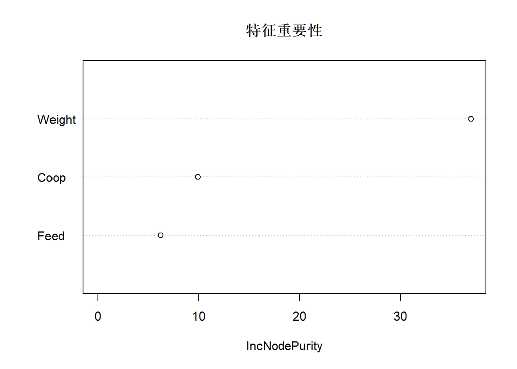

```r
# 3. 特征重要性图
varImpPlot(rf_mod, main="特征重要性")
```

```r
# 4. 测试集预测 + 计算RMSE
pred_rf <- predict(rf_mod, newdata = test_data)
rmse_rf <- sqrt(mean((pred_rf - test_data$Egg_Count)^2))
cat("随机森林测试集RMSE = ", rmse_rf, "\n")
```

```
## 随机森林测试集RMSE =  5.668815
```

```r
set.seed(123)
k <- 5
rmse_vec <- c()
for(i in 1:k){
  idx <- sample(1:n, size=0.7*n, replace=F)
  train_k <- clean_data[idx,]
  test_k  <- clean_data[-idx,]
  rf_k <- randomForest(Egg_Count ~ Coop + Feed + Weight, data=train_k, ntree=300)
  pred_k <- predict(rf_k, test_k)
  rmse_vec[i] <- sqrt(mean((pred_k - test_k$Egg_Count)^2))
}
rmse_vec
```

```
## [1] 5.685831 5.336608 4.469729 3.846433 3.020566
```

```r
mean_cv_rmse <- mean(rmse_vec)
cat("5折交叉验证平均RMSE：", mean_cv_rmse, "\n")
```

```
## 5折交叉验证平均RMSE： 4.471833
```

##6.2 真实值 vs 预测值散点图（拓展新增，45° 基准线）

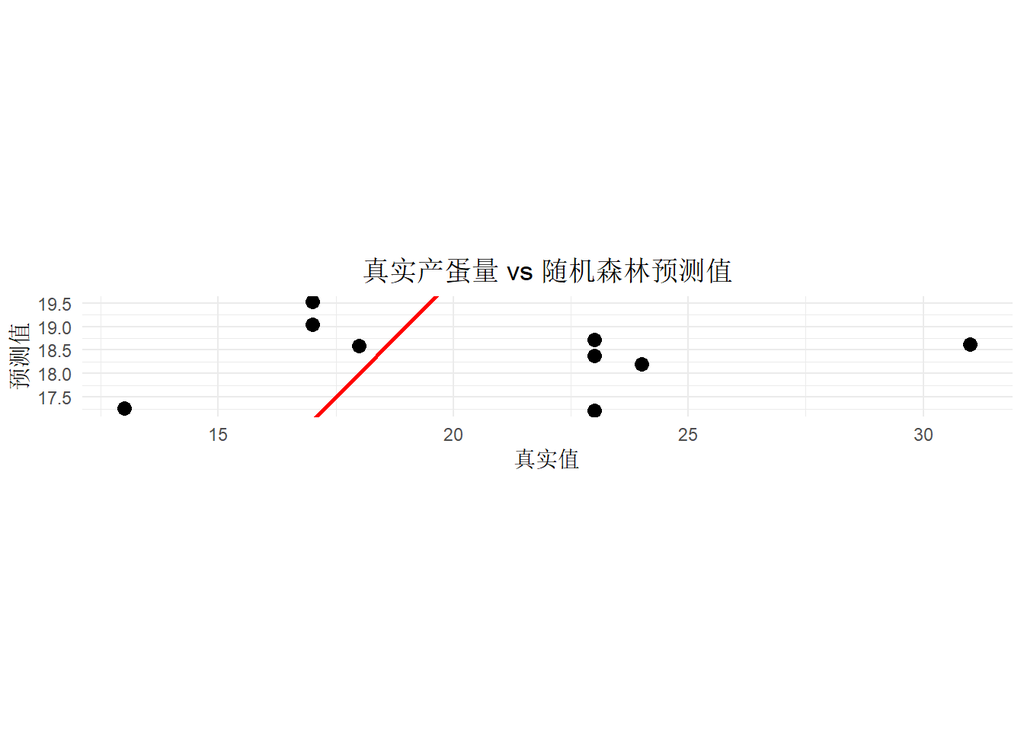

```r
df_pred <- data.frame(
  real = test_data$Egg_Count,
  pred = pred_rf
)

ggplot(df_pred, aes(x=real, y=pred)) +
  geom_point(size=3) +
  geom_abline(slope=1, intercept=0, color="red", linewidth=1) +
  coord_fixed(ratio=1) +
  labs(title="真实产蛋量 vs 随机森林预测值", x="真实值", y="预测值") +
  theme_minimal() +
  theme(plot.title = element_text(hjust = 0.5))
```